# Indeks og indekskonstruktion

Metode 1 F25 #6

Søren Damsbo-Svendsen

19. marts 2025

## Housekeeping

- **Tabeller kan også være gode til datavisualisering** (se MIS)
  - især når det skal være eksakt eller til reference
  - fx databeskrivelse eller regressionstabeller (statistiske *resultater*)
  - eller simple analyser med krydstabeller (to variable, fx ja/nej → firfeltstabel med frekvenser)
  - i dag har jeg mange tabeller med
- **Data** fra VU til mine eksempler → download selv på Rigsarkivet<sup>1</sup> og prøv
- **Skriveøvelsen:** mange små delelementer, implicit hjælp i dag
[^1]: https://digidata.rigsarkivet.dk/aflevering/51035

## Temaer

- Indeks
  - indekskonstruktion
  - måling
  - målingsvaliditet og -reliabilitet
  - refleksivt/formativt
  - indeksanalyse:
    - item-item-korrelation
    - item-skala-korrelation
    - Cronbach’s *alpha*
- Faktoranalyse

## Hovedpointer

- **Indeks er et enormt smart redskab til at forbedre vores målinger af teoretiske begreber**
  - både fordele og ulemper, men i mange tilfælde er fordelene størst
- Ideen er ganske enkel, men så er det alligevel lidt kompliceret i praksis
  - ofte volder det problemer at holde styr på variablenes *manglende værdier*, *retning* og *bredde*
  - indekskonstruktion og -analyse er egentlig nemt nok

## Plan for forelæsningen

1. Recap af dataviz med **ggplot2** og en smule om **data i R**
2. **Hvad er et indeks**
3. Et længere eksempel på **indekskonstruktion i R**
4. Eksempler fra litteraturen
5. **Faktoranalyse**

## Recap: (gg)plottets anatomi

**A layered grammar of graphics** (Wickham 2008):

1. A default **dataset** and set of mappings from variables to **aesthetics**
2. One or more **layers**, each composed of a **geometric object**, a statistical transformation*, and a position adjustment*, and optionally, a dataset* and aesthetic mappings*
3. One **scale*** for each aesthetic mapping used
4. A **coordinate system***
5. A **faceting*** specification

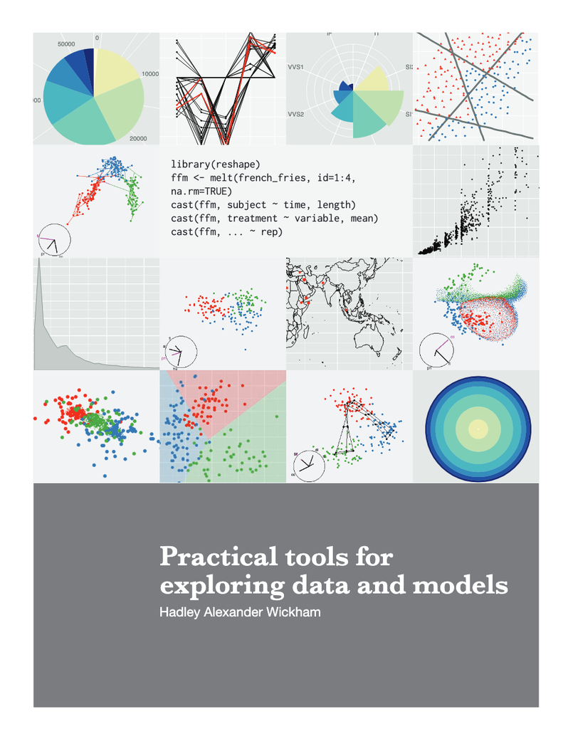

```r
# basalt ggplot call:
data |>                     #1
  ggplot() +
  aes(x = var1, y = var2) + #1
  geom_point() +            #2
  scale_x_continuous() +    #3*
  coord_cartesian() +       #4*
  facet_wrap(~ var3)        #5*

# OBS! der bruges '+' i ggplot
# rækkefølgen er (næsten) underordnet
```

# Data i R

1. Fil-/projekthåndtering
   - getwd(), setwd(), “” *tab*, read_*()
2. Basal datamanipulation med dplyr (tidyverse)
   - select, arrange, **filter**, **mutate**, summarise, group_by

## Fil-/projekthåndtering

- lav en ny mappe til projektet og gem *alle* projektets filer dér
- lav gerne undermapper (fx ‘data’, ‘plots’)
- når det er sat rigtigt op, leder R altid efter filer (og gemmer nye) i projektmappen
- hvis du åbner et R-script, der ligger i projektmappen, starter R dér (= *working directory*)
- du kan tjekke *working directory* (den aktive projektmappe) med *getwd()*
- eller indstille den med *setwd(“sti_til_projektmappen”)*
  - så kan R finde rundt (med ‘relative stier’)
- mellem “” kan du med *tab* (auto-complete) ‘søge’ dig frem til filer
  - hvis du starter med “../”, går den et niveau op, ud af mappen

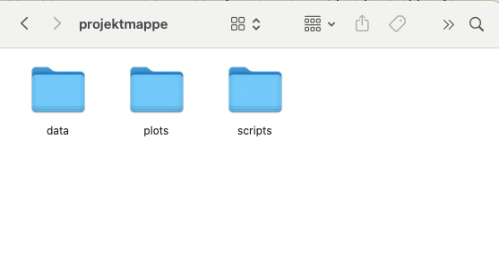

## Fil-/projekthåndtering

Når du skal indlæse en datafil, skal du kende:

1. dens **filnavn**: fx ‘Dataset.dta’
2. dens absolutte eller relative **sti** (inden for projektmappen/wd):
   - ‘~/uni/projektmappe/data/Dataset.dta’
   - ‘data/Dataset.dta’
3. dens **filtype** → afgør hvilken R-funktion du skal bruge
   - dat <- haven::read_dta(“data/Dataset.dta”) # stata (ofte smart pga. labels)
   - dat <- readxl::read_excel(“data/Dataset.xlsx”) # excel
   - dat <- readr::read_rds(“data/Dataset.rds”) # R
   - dat <- readr::read_csv(“data/Dataset.csv”) # csv (komma)
   - dat <- readr::read_csv2(“data/Dataset.csv”) # csv (semikolon)
   - samme for SAS, SPSS, txt, etc.
   - (.RData-filer dobbeltklikker man bare på)

## Basal datamanipulation med dplyr (tidyverse)

- `select:` vælger eller fravælger (sletter) kolonner
  - også kolonnernes rækkefølge
  - mange smarte måder at bruge select
  - select(var1, var2, var11, var5, -var20)
- `arrange:` sorterer rækkerne betinget af en eller flere variable
  - arrange(var2, desc(var11))
- `filter:` nøglefunktionen til at fjerne – eller beholde – enheder/rækker baseret på deres værdier på en eller flere variable
  - fx til at fjerne NA, eller en vis aldersgruppe eller “Ved ikke”
  - eller til at beholde valide/udvalgte værdier
  - ! betyder ‘ikke’, komma adskiller vores ‘filtre’
  - filter(!is.na(var1), alder < 50, spg5 %in% c(1,2,3,4,5))

## Basal datamanipulation med dplyr (tidyverse)

- `mutate()`: nøglefunktionen til at konstruere/ændre variable på enhver måde  
  (i samme *dataframe*)
  - power duo når `mutate()` kombineres den med `ifelse()`
- `summarise`: nøglefunktionen til at opsummere data/variable, fx lave deskriptiv statistik (skaber en ny, mindre *dataframe*)
  - bruges sammen med statistik-funktioner o.l.: mean, median, first, min, max, etc.
- `group_by:` brug filter, mutate, summarise etc. *inden for* grupper defineret ved en variabel, fx til at beregne gennemsnit for hvert parti:
  - `group_by(parti) |> summarise(gns = mean(var1)) |> ungroup()`
  - altid godt at køre `ungroup()` bagefter for at droppe gruppestrukturen og undgå fejl

## Basal datamanipulation med dplyr (tidyverse)

- select, arrange, filter, mutate, summarise, group_by er et godt udgangspunkt
- Essentielt at kunne anvende disse (og relaterede) funktioner
  - i R generelt, i ggplot, i statistiske analyser osv.
- Læs Larsen (2024) og lav øvelserne
- Se YouTube og find online tutorials, spørg ChatGPT
- Gå til kilden → Hadley Wickham (of course):  
  https://r4ds.hadley.nz/data-transform.html

# Indeks og indekskonstruktion

## Operationalisering og måling — eksempel

- **Teoretisk begreb**: (gruppebaseret) *politisk respekt*
- **Operationaliseret variabel**: “*I hvilket omfang synes du, at [ældre/unge, byen/landet m.fl.] bliver mødt med den respekt fra samfundet, som de fortjener?*” Fra 0 (slet ikke) til 10 (i meget høj grad)

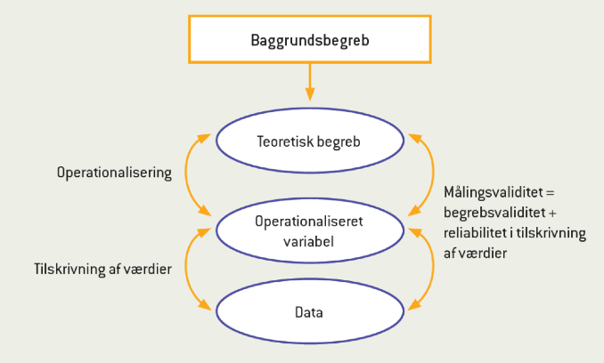

MIS figur 4.1

### Hvad nu hvis:

- det virker umuligt at indfange det **latente teoretiske begreb** med et enkelt spørgsmål?
- vi er bange for at spørgsmålet er svært at svare på, eller svarene har meget **tilfældig støj**?
- det bare er for svært at udvælge **det helt rigtige spørgsmål**, og der er flere relevante spørgsmål til rådighed?
- vi er for nervøse ved at behandle vores **ordinale variabel** som intervalskaleret?

## Operationalisering og måling — eksempel

- **Teoretisk begreb**: (gruppebaseret) *politisk respekt*
- **Operationaliseret variabel**: “*I hvilket omfang synes du, at [ældre/unge, byen/landet m.fl.] bliver mødt med den respekt fra samfundet, som de fortjener?*” Fra 0 (slet ikke) til 10 (i meget høj grad)

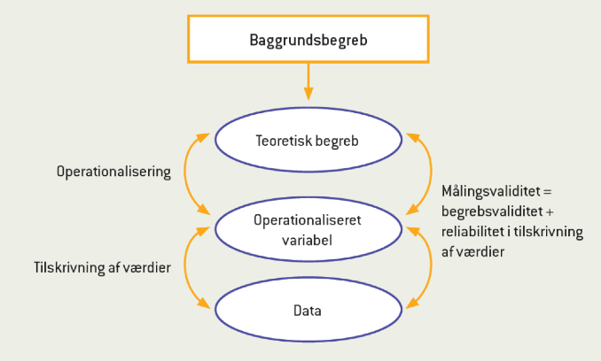

MIS figur 4.1

### Svar: Lav et indeks!

- find **min. 2 og gerne flere** (~3-10) spørgsmål/indikatorer, der kredser om det samme
- kombiner dem i et indeks
- skaber ofte en **bedre måling**, givet den nødvendige **kvalitetssikring**  
  (*målingsvaliditet* og intern konsistens/*reliabilitet*)

## Indeks og indekskonstruktion

- Sofistikeret, men også enkel tilgang til **måling af teoretiske begreber**
- **Latent** (uobserverbar) *variabel/koncept/begreb* måles  
  vha. observerbare *indikatorer/variable/spørgsmål* (items)
- **Formativt** vs. **refleksivt**
  - indikatorne kan være de samme, men **modellen/konceptualiseringen** er vidt forskellig:
  - i et **formativt indeks** er *den latente variabel* produkt af indikatorerne
  - i et **refleksivt indeks** er indikatorerne produkter af den latente variabel
  - vigtig implikation:  
    nødvendigvis korrelation mellem indikatorer i **refleksivt**,  
    men ikke **formativt**
  - **formativt** kræver særdeles grundig teoretisk argumentation, **refleksivt** er lidt mere tilgivende – og meget mere anvendt
- (additivt) indeks ≈ scale/skala

## Indeks og indekskonstruktion

- Fordele:
  - *kan* reducere reliabilitetsproblemer
  - *kan* øge målingsvaliditeten
  - målingen bliver ‘mere intervalskaleret’
  - potentielt effektivt til at overkomme manglende værdier
- Ulemper:
  - mere kompliceret – også fortolkning/formidling
  - mindre transparent
  - potentielt tidskrævende
  - potentielt mere *ad hoc*, mindre replicerbart

## Indekskonstruktion i praksis

1. **Udvælgelse:** *find og tjek* variable
   - spørgsmål, måleniveauer, kategorier, potentielt manglende værdier
2. **Rensning:** identificer *missing* og kod som *NA*
3. **Rensning:** *omskalering* til samme retning (og bredde)
4. **Rensning:** *håndtering* af missing/*NA* → find, tæl, imputer, fjern
5. **Indekskonstruktion:** *beregn* gennemsnit/sum af items (vær obs på *NA*s)
6. **Omskalering:** vælg en god *skala*
7. **Indeksanalyse:**
   - *overblik* over den nye indeks-variabel
   - beregn korrelationer, Cronbach’s *alpha* → diskussion af *målingsvaliditet* og -*reliabilitet*
   - fjern evt. ‘dårlige’ indikatorer og gå tilbage til (5)
8. (Brug indekset som (u)afhængig variabel i hovedanalysen…)

*Note: rækkefølgen kan variere*

# Det store eksempel – egalitarisme

## Det store eksempel – egalitarisme

1. Jeg er interesseret i danskernes holdning til økonomisk (u)lighed, eller hvad man kunne kalde **egalitarisme** (teoretisk begreb)
2. Jeg har ikke mulighed for at lave min egen survey, men har fundet **valgundersøgelsen** (den største danske holdningstidsserie)
3. Jeg har browset grundigt rundt i valgundersøgelsens dokumentation (pdf-filen med spørgeskemaet)
4. Jeg har udvalgt **tre variable**, som virker særligt *relevante* og forholdsvist *unidimensionelle*:
   - 49.10) *Økonomisk **ulighed** gavner samfundet*
   - 49.2) *I politik bør man stræbe efter at skaffe alle de samme økonomiske **vilkår**, uanset uddannelse og beskæftigelse*
   - 49.13) *For at skabe **dynamik** og fremgang i samfundet må man acceptere en vis grad af ulighed*

## Find og tjek variable

**Kode**

```r
library(labelled)

vu_egal1 <- vu |>
  mutate(id = Løbenummer,
         egal_ulighed = Q49_9,
         egal_vilkaar = Q49_2,
         egal_dynamik = Q49_12) |>
  select(id, starts_with("egal"))

generate_dictionary(vu_egal1)
```

```
 pos variable     label                    col_type values
 1   id           Ikke betydningsbærende ~ dbl
 2   egal_ulighed Hvor enig eller uenig e~ dbl+lbl  [1] Helt enig
                                                    [2] Nærmest enig
                                                    [3] Hverken enig eller ~
                                                    [4] Nærmest uenig
                                                    [5] Helt uenig
                                                    [99] Ved ikke
                                                    [777] Ugyldigt svar
 3   egal_vilkaar Hvor enig eller uenig e~ dbl+lbl  [1] Helt enig
                                                    [2] Nærmest enig
                                                    [3] Hverken enig eller ~
                                                    [4] Nærmest uenig
                                                    [5] Helt uenig
                                                    [99] Ved ikke
                                                    [777] Ugyldigt svar
 4   egal_dynamik Hvor enig eller uenig e~ dbl+lbl  [1] Helt enig
                                                    [2] Nærmest enig
                                                    [3] Hverken enig eller ~
                                                    [4] Nærmest uenig
                                                    [5] Helt uenig
                                                    [99] Ved ikke
```

## Find og tjek variable

**Kode**

```r
vu_egal1 |>
  count(egal_ulighed)
```

```
# A tibble: 6 × 2
  egal_ulighed                      n
  <dbl+lbl>                     <int>
1  1 [Helt enig]                   96
2  2 [Nærmest enig]               364
3  3 [Hverken enig eller uenig]   662
4  4 [Nærmest uenig]              494
5  5 [Helt uenig]                 825
6 NA                              382
```

**Kode**

```r
vu_egal1 |>
  count(egal_vilkaar)
```

```
# A tibble: 6 × 2
  egal_vilkaar                      n
  <dbl+lbl>                     <int>
1  1 [Helt enig]                  287
2  2 [Nærmest enig]               537
3  3 [Hverken enig eller uenig]   592
4  4 [Nærmest uenig]              587
5  5 [Helt uenig]                 460
6 NA                              360
```

**Kode**

```r
vu_egal1 |>
  count(egal_dynamik)
```

```
# A tibble: 6 × 2
  egal_dynamik                      n
  <dbl+lbl>                     <int>
1  1 [Helt enig]                  345
2  2 [Nærmest enig]               882
3  3 [Hverken enig eller uenig]   608
4  4 [Nærmest uenig]              358
5  5 [Helt uenig]                 288
6 NA                              342
```

## Find og tjek variable

**Kode**

```r
p1 <- vu_egal1 |>
  count(egal_ulighed) |>
  ggplot() +
  aes(x = to_factor(egal_ulighed), y = n) +
  geom_col() +
  ggthemes::theme_tufte() +
  theme(axis.text.x = element_text(angle = 90, hjust = 1)) +
  labs(x = NULL, y = NULL,
       subtitle = str_wrap("Økonomisk ulighed gavner samfundet", 40))

p2 <- vu_egal1 |>
  count(egal_vilkaar) |>
  ggplot() +
  aes(x = to_factor(egal_vilkaar), y = n) +
  geom_col() +
  ggthemes::theme_tufte() +
  theme(axis.text.x = element_text(angle = 90, hjust = 1)) +
  labs(x = NULL, y = NULL,
       subtitle = str_wrap("I politik bør man stræbe efter at skaffe alle de samme økonomiske vilkår, uanset uddannelse og beskæftigelse", 40))

p3 <- vu_egal1 |>
  count(egal_dynamik) |>
  ggplot() +
  aes(x = to_factor(egal_dynamik), y = n) +
  geom_col() +
  ggthemes::theme_tufte() +
  theme(axis.text.x = element_text(angle = 90, hjust = 1)) +
  labs(x = NULL, y = NULL,
       subtitle = str_wrap("For at skabe dynamik og fremgang i samfundet må man acceptere en vis grad af ulighed", 40))



p1 + p2 + p3
```

## Find og tjek variable

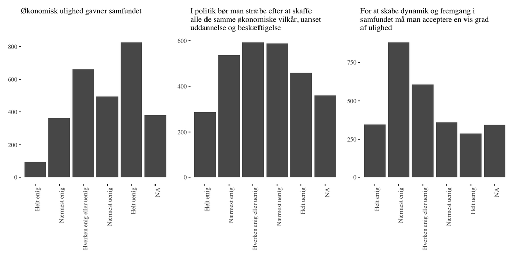

## Identificer missing og kod som NA (i første omgang)

**Kode**

```r
vu_egal2 <- vu_egal1 |>
  mutate(egal_ulighed = ifelse(egal_ulighed > 5, NA, egal_ulighed),
         egal_vilkaar = ifelse(egal_vilkaar > 5, NA, egal_vilkaar),
         egal_dynamik = ifelse(egal_dynamik > 5, NA, egal_dynamik))
```

- *Missing værdier er allerede kodet som NA*
- Koden ovenfor ville have kodet alle værdier over 5 som missing
- (fx 99 Ved ikke, 777 Ugyldigt svar)

## Omskalering til samme retning (og bredde)

Hvilken retning er for **mere lighed** (mere af det teoretiske begreb)?

- egal_ulighed (1-5): 5 (uenig) er mest lighed
- **egal_vilkaar (1-5): 1 (enig) er mest lighed → den skal vendes!**
- egal_dynamik (1-5): 5 (uenig) er mest lighed

**Kode**

```r
library(scales)

vu_egal3 <- vu_egal2 |>
  # fjern labels (det kan nogle R-funktioner bedst lide, og vi har fået overblikket, så vi klarer os)
  mutate(egal_vilkaar = remove_labels(egal_vilkaar),
         egal_dynamik = remove_labels(egal_dynamik),
         egal_ulighed = remove_labels(egal_ulighed)) |>
  # omskaler egal_vilkaar, som vendte omvendt
  # scales::rescale() kan både anvendes til at vende skalaen og strække/sammenpresse den
  mutate(egal_vilkaar = scales::rescale(egal_vilkaar, to = c(5, 1)))
```

## Omskalering til samme retning (og bredde)

**Kode**

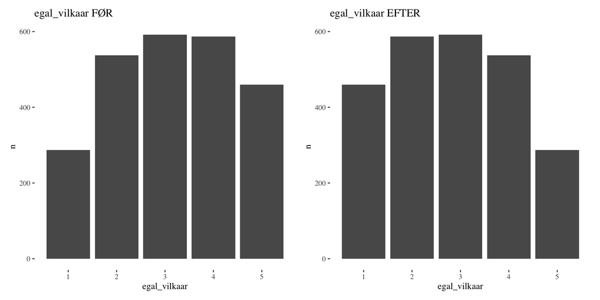

```r
p1 <- vu_egal2 |>
  count(egal_vilkaar) |>
  ggplot() +
  aes(x = egal_vilkaar, y = n) +
  geom_col() +
  labs(title = "egal_vilkaar FØR")  +
  ggthemes::theme_tufte()

p2 <- vu_egal3 |>
  count(egal_vilkaar) |>
  ggplot() +
  aes(x = egal_vilkaar, y = n) +
  geom_col() +
  labs(title = "egal_vilkaar EFTER") +
  ggthemes::theme_tufte()

p1 + p2
```

## Omskalering til samme retning (og bredde)

*Hvad hvis de andre variable, havde været målt på en 0-10 skala?*

Så havde vi bare skrevet `to = c(10, 0)` i stedet for `to = c(5, 1)`:

**Kode**

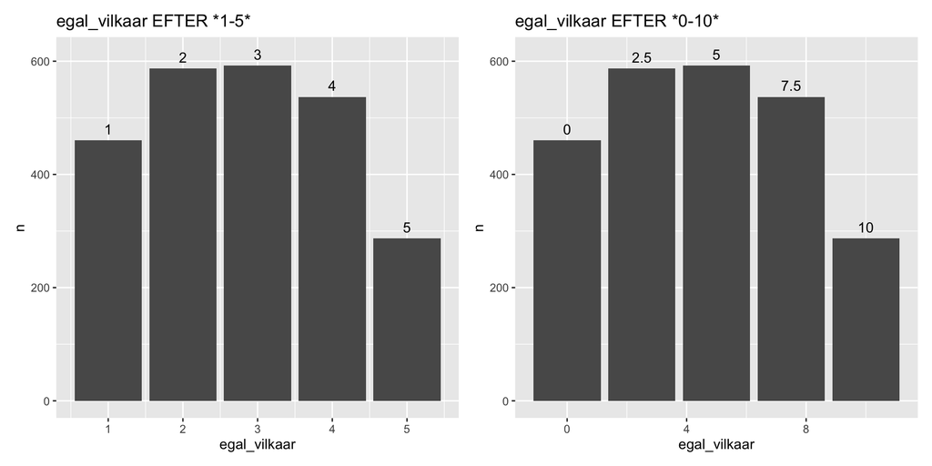

```r
p1 <- vu_egal3 |>
  count(egal_vilkaar) |>
  ggplot() +
  aes(x = egal_vilkaar, y = n) +
  geom_col() +
  geom_text(aes(label = egal_vilkaar, y = n + 20)) +
  labs(title = "egal_vilkaar EFTER *1-5*")

p2 <- vu_egal2 |>
  mutate(egal_vilkaar = scales::rescale(egal_vilkaar, to = c(10, 0))) |> # 10 til 0 i stedet for 5 til 1
  count(egal_vilkaar) |>
  ggplot() +
  aes(x = egal_vilkaar, y = n) +
  geom_col() +
  geom_text(aes(label = egal_vilkaar, y = n + 20)) +
  labs(title = "egal_vilkaar EFTER *0-10*")

p1 + p2
```

## Håndtering af missing

> Hvad gør vi med de enheder (fx respondenter), som har manglende værdier på *nogle*, men *ikke alle* de valgte items?

*Man kan ikke lave beregninger på manglende værdier…*

1. Skal indekset også have en *missing*-værdi, når blot der mangler en enkelt værdi?
   - husk at enheden så ryger helt ud af de fleste analyser
2. Skal vi selv give *missing*-værdier en bestemt værdi, før vi laver beregninger?
   - jamen hvilken værdi?
3. Skal vi ignorere *missing* og beregne indeksværdien pba. resten af vores items?
   - kan det ikke blive lidt misvisende (skabe målefejl)?
4. Kan vi finde en mellemvej, der ikke ekskluderer for mange (1),  
   men stiller flere krav end (2) og (3)?
   - spoiler: ja – men ikke nødvendigvis bedre end (1)-(3)

## Håndtering af missing

> Hvad gør vi med de enheder (fx respondenter), som har manglende værdier på *nogle*, men *ikke alle* de valgte items?
- Ofte beregner vi indekset ud fra de målinger, der nu engang *er* valide, når bare der mindst er én valid værdi (3)
  - stor fordel ved indeks med denne – lidt liberale – tilgang:  
    målinger fra en stor del af samplet
  - vi må tage stilling hver gang
  - og passe på i R-koden!

**Kode**

```r
bind_rows(
  tidystats::describe_data(vu_egal3, egal_ulighed),
  tidystats::describe_data(vu_egal3, egal_dynamik),
  tidystats::describe_data(vu_egal3, egal_vilkaar)
) |>  # der mangler mange værdier
  kable(digits = 2) |>
  kableExtra::kable_styling(font_size = 22) |>
  kableExtra::column_spec(2, background = "pink")
```

| var | missing | N | M | SD | SE | min | max | range | median | mode | skew | kurtosis |
| --- | --- | --- | --- | --- | --- | --- | --- | --- | --- | --- | --- | --- |
| egal_ulighed | 382 | 2441 | 3.65 | 1.20 | 0.02 | 1 | 5 | 4 | 4 | 5 | -0.37 | 2.04 |
| egal_dynamik | 342 | 2481 | 2.74 | 1.21 | 0.02 | 1 | 5 | 4 | 3 | 2 | 0.42 | 2.25 |
| egal_vilkaar | 360 | 2463 | 2.84 | 1.28 | 0.03 | 1 | 5 | 4 | 3 | 3 | 0.10 | 1.92 |

## Indekskonstruktion og håndtering af missing

- I praksis er indekskonstruktion og håndtering af missing sammenvævet
- Den ‘nemme’ del af **indekskonstruktionen** er at beregne en samlet værdi
  - stort set altid bare *gennemsnit* eller *sum*
- Men – igen – hvad med de enheder, som mangler nogle værdier?
- **Lad os se på et udsnit af data:**

| id | egal_ulighed | egal_vilkaar | egal_dynamik |
| --- | --- | --- | --- |
| 2790 | NA | NA | NA |
| 2364 | 4 | 5 | 4 |
| 632 | 3 | NA | 3 |
| 183 | 3 | 5 | 3 |
| 1699 | 4 | 4 | 2 |
| 582 | 5 | 4 | 4 |
| 2039 | 2 | 4 | 5 |
| 2156 | NA | 2 | 3 |
| 2684 | 3 | 3 | 3 |
| 2751 | 2 | 1 | 5 |

## Indekskonstruktion og håndtering af missing I

> Først prøver vi at konstruere indekset som en **simpel sum** (egal_indeks_raw) – og omskalere til 1-5 (egal_indeks)

**Kode**

```r
vu_egal4 <- vu_egal3 |>
  mutate(egal_indeks_raw = egal_ulighed + egal_vilkaar + egal_dynamik,
         egal_indeks = scales::rescale(egal_indeks_raw, to = c(1, 5)))
```

| id | egal_ulighed | egal_vilkaar | egal_dynamik | egal_indeks_raw | egal_indeks |
| --- | --- | --- | --- | --- | --- |
| 2790 | NA | NA | NA | NA | NA |
| 2364 | 4 | 5 | 4 | 13 | 4.3 |
| 632 | 3 | NA | 3 | NA | NA |
| 183 | 3 | 5 | 3 | 11 | 3.7 |
| 1699 | 4 | 4 | 2 | 10 | 3.3 |
| 582 | 5 | 4 | 4 | 13 | 4.3 |
| 2039 | 2 | 4 | 5 | 11 | 3.7 |
| 2156 | NA | 2 | 3 | NA | NA |
| 2684 | 3 | 3 | 3 | 9 | 3.0 |
| 2751 | 2 | 1 | 5 | 8 | 2.7 |

## Indekskonstruktion og håndtering af missing I

> Først prøver vi at konstruere indekset som en **simpel sum** (egal_indeks_raw) – og omskalere til 1-5 (egal_indeks)

**Kode**

```r
bind_rows(
  tidystats::describe_data(vu_egal4, egal_ulighed),
  tidystats::describe_data(vu_egal4, egal_dynamik),
  tidystats::describe_data(vu_egal4, egal_vilkaar),
  tidystats::describe_data(vu_egal4, egal_indeks)) |>  # nu mangler der endnu flere værdier...
  kable(digits = 2) |>
  kableExtra::kable_styling(font_size = 22) |>
  kableExtra::column_spec(2, background = "pink")
```

| var | missing | N | M | SD | SE | min | max | range | median | mode | skew | kurtosis |
| --- | --- | --- | --- | --- | --- | --- | --- | --- | --- | --- | --- | --- |
| egal_ulighed | 382 | 2441 | 3.65 | 1.20 | 0.02 | 1 | 5 | 4 | 4 | 5 | -0.37 | 2.04 |
| egal_dynamik | 342 | 2481 | 2.74 | 1.21 | 0.02 | 1 | 5 | 4 | 3 | 2 | 0.42 | 2.25 |
| egal_vilkaar | 360 | 2463 | 2.84 | 1.28 | 0.03 | 1 | 5 | 4 | 3 | 3 | 0.10 | 1.92 |
| egal_indeks | 612 | 2211 | 3.08 | 0.97 | 0.02 | 1 | 5 | 4 | 3 | NA | 0.06 | 2.33 |

## Indekskonstruktion og håndtering af missing II

> Så prøver vi at give missing-værdier en ny værdi—**gennemsnittet hos alle andre enheder**—før vi konstruerer indekset som en **simpel sum**

**Kode**

```r
vu_egal5 <- vu_egal3 |>
  mutate(
    # erstat missing-værdier med variablens gennemsnit vha. ifelse()
    egal_ulighed = ifelse(is.na(egal_ulighed), mean(egal_ulighed, na.rm = TRUE), egal_ulighed),
    egal_vilkaar = ifelse(is.na(egal_vilkaar), mean(egal_vilkaar, na.rm = TRUE), egal_vilkaar),
    egal_dynamik = ifelse(is.na(egal_dynamik), mean(egal_dynamik, na.rm = TRUE), egal_dynamik),
    # indekskonstruktion igen
    egal_indeks_raw = egal_ulighed + egal_vilkaar + egal_dynamik,
    egal_indeks = scales::rescale(egal_indeks_raw, to = c(1, 5)))
```

| id | egal_ulighed | egal_vilkaar | egal_dynamik | egal_indeks_raw | egal_indeks |
| --- | --- | --- | --- | --- | --- |
| 2790 | 3.7 | 2.8 | 2.7 | 9.2 | 3.1 |
| 2364 | 4.0 | 5.0 | 4.0 | 13.0 | 4.3 |
| 632 | 3.0 | 2.8 | 3.0 | 8.8 | 2.9 |
| 183 | 3.0 | 5.0 | 3.0 | 11.0 | 3.7 |
| 1699 | 4.0 | 4.0 | 2.0 | 10.0 | 3.3 |
| 582 | 5.0 | 4.0 | 4.0 | 13.0 | 4.3 |
| 2039 | 2.0 | 4.0 | 5.0 | 11.0 | 3.7 |
| 2156 | 3.7 | 2.0 | 3.0 | 8.7 | 2.9 |
| 2684 | 3.0 | 3.0 | 3.0 | 9.0 | 3.0 |
| 2751 | 2.0 | 1.0 | 5.0 | 8.0 | 2.7 |

## Indekskonstruktion og håndtering af missing II

> Så prøver vi at give missing-værdier en ny værdi—**gennemsnittet hos alle andre enheder**—før vi konstruerer indekset som en **simpel sum**

**Kode**

```r
bind_rows(
  tidystats::describe_data(vu_egal5, egal_ulighed),
  tidystats::describe_data(vu_egal5, egal_dynamik),
  tidystats::describe_data(vu_egal5, egal_vilkaar),
  tidystats::describe_data(vu_egal5, egal_indeks)) |>  # nu mangler der endnu flere værdier...
  kable(digits = 2) |>
  kableExtra::kable_styling(font_size = 22) |>
  kableExtra::column_spec(2, background = "pink")
```

| var | missing | N | M | SD | SE | min | max | range | median | mode | skew | kurtosis |
| --- | --- | --- | --- | --- | --- | --- | --- | --- | --- | --- | --- | --- |
| egal_ulighed | 0 | 2823 | 3.65 | 1.12 | 0.02 | 1 | 5 | 4 | 3.65 | 5 | -0.40 | 2.36 |
| egal_dynamik | 0 | 2823 | 2.74 | 1.13 | 0.02 | 1 | 5 | 4 | 2.74 | 2 | 0.45 | 2.56 |
| egal_vilkaar | 0 | 2823 | 2.84 | 1.20 | 0.02 | 1 | 5 | 4 | 3.00 | 3 | 0.11 | 2.20 |
| egal_indeks | 0 | 2823 | 3.08 | 0.89 | 0.02 | 1 | 5 | 4 | 3.00 | 3 | 0.05 | 2.66 |

## Indekskonstruktion og håndtering af missing III

> Så prøver vi en (lidt farlig) genvej og beregner indekset som et **gennemsnit, der blot ignorerer missing**

| id | egal_ulighed | egal_vilkaar | egal_dynamik |
| --- | --- | --- | --- |
| 2790 | NA | NA | NA |
| 2364 | 4 | 5 | 4 |
| 632 | 3 | NA | 3 |
| 183 | 3 | 5 | 3 |
| 1699 | 4 | 4 | 2 |
| 582 | 5 | 4 | 4 |
| 2039 | 2 | 4 | 5 |
| 2156 | NA | 2 | 3 |
| 2684 | 3 | 3 | 3 |
| 2751 | 2 | 1 | 5 |

## Indekskonstruktion og håndtering af missing III

> Så prøver vi en (lidt farlig) genvej og beregner indekset som et **gennemsnit, der blot ignorerer missing**

**Kode**

```r
vu_egal6 <- vu_egal3 |>
  rowwise() |> # gruppér (og beregn derefter) inden rækker
  mutate(egal_indeks = mean(c(egal_ulighed, egal_vilkaar, egal_dynamik), na.rm = TRUE)) |> # OBS! mean(), ikke sum()
  ungroup()
```

| id | egal_ulighed | egal_vilkaar | egal_dynamik | egal_indeks |
| --- | --- | --- | --- | --- |
| 2790 | NA | NA | NA | NaN |
| 2364 | 4 | 5 | 4 | 4.3 |
| 632 | 3 | NA | 3 | 3.0 |
| 183 | 3 | 5 | 3 | 3.7 |
| 1699 | 4 | 4 | 2 | 3.3 |
| 582 | 5 | 4 | 4 | 4.3 |
| 2039 | 2 | 4 | 5 | 3.7 |
| 2156 | NA | 2 | 3 | 2.5 |
| 2684 | 3 | 3 | 3 | 3.0 |
| 2751 | 2 | 1 | 5 | 2.7 |

## Indekskonstruktion og håndtering af missing III

> Så prøver vi en (lidt farlig) genvej og beregner indekset som et **gennemsnit, der blot ignorerer missing**

**Kode**

```r
bind_rows(
  tidystats::describe_data(vu_egal6, egal_ulighed),
  tidystats::describe_data(vu_egal6, egal_dynamik),
  tidystats::describe_data(vu_egal6, egal_vilkaar),
  tidystats::describe_data(vu_egal6, egal_indeks)) |>  # nu mangler der endnu flere værdier...
  kable(digits = 2) |>
  kableExtra::kable_styling(font_size = 22) |>
  kableExtra::column_spec(2, background = "pink")
```

| var | missing | N | M | SD | SE | min | max | range | median | mode | skew | kurtosis |
| --- | --- | --- | --- | --- | --- | --- | --- | --- | --- | --- | --- | --- |
| egal_ulighed | 382 | 2441 | 3.65 | 1.20 | 0.02 | 1 | 5 | 4 | 4 | 5 | -0.37 | 2.04 |
| egal_dynamik | 342 | 2481 | 2.74 | 1.21 | 0.02 | 1 | 5 | 4 | 3 | 2 | 0.42 | 2.25 |
| egal_vilkaar | 360 | 2463 | 2.84 | 1.28 | 0.03 | 1 | 5 | 4 | 3 | 3 | 0.10 | 1.92 |
| egal_indeks | 181 | 2642 | 3.08 | 1.00 | 0.02 | 1 | 5 | 4 | 3 | 3 | 0.08 | 2.33 |

## Indekskonstruktion og håndtering af missing III

### Hvorfor *mean(…, na.rm = TRUE)* og ikke *sum(…, na.rm = TRUE)*?

- I teorien lige gode
  - og ækvivalente hvis man omskalerer
- Men i R er *sum()* med *na.rm = TRUE* et stort problem
  - fejl i bogen (?)
- Stor risiko for alvorlige systematiske målefejl
  - især hvis mange enheder har missing
- Derudover giver *mean()* samme skala som vores items, hvor *sum()* skal omskaleres
- **Lad os lige sammenligne *sum()* og *mean()* for at forstå problemet:**

## Indekskonstruktion og håndtering af missing III

**Kode**

```r
vu_egal9a <- vu_egal3 |>
  rowwise() |> # gruppér (og beregn derefter) inden rækker
  mutate(egal_indeks_meanNA = mean(c(egal_ulighed, egal_vilkaar, egal_dynamik), na.rm = TRUE),
         egal_indeks_sumNA_raw = sum(c(egal_ulighed, egal_vilkaar, egal_dynamik), na.rm = TRUE)) |>
  ungroup() |>
  mutate(egal_indeks_sumNA = scales::rescale(egal_indeks_sumNA_raw, to = c(1, 5)))
```

| id | egal_ulighed | egal_vilkaar | egal_dynamik | egal_indeks_meanNA | egal_indeks_sumNA_raw | egal_indeks_sumNA |
| --- | --- | --- | --- | --- | --- | --- |
| 2790 | NA | NA | NA | NaN | 0 | 1.0 |
| 2364 | 4 | 5 | 4 | 4.3 | 13 | 4.5 |
| 632 | 3 | NA | 3 | 3.0 | 6 | 2.6 |
| 183 | 3 | 5 | 3 | 3.7 | 11 | 3.9 |
| 1699 | 4 | 4 | 2 | 3.3 | 10 | 3.7 |
| 582 | 5 | 4 | 4 | 4.3 | 13 | 4.5 |
| 2039 | 2 | 4 | 5 | 3.7 | 11 | 3.9 |
| 2156 | NA | 2 | 3 | 2.5 | 5 | 2.3 |
| 2684 | 3 | 3 | 3 | 3.0 | 9 | 3.4 |
| 2751 | 2 | 1 | 5 | 2.7 | 8 | 3.1 |

## Indekskonstruktion og håndtering af missing III

| var | missing | N | M | SD | SE | min | max | range | median | mode | skew | kurtosis |
| --- | --- | --- | --- | --- | --- | --- | --- | --- | --- | --- | --- | --- |
| egal_indeks_meanNA | 181 | 2642 | 3.08 | 1.00 | 0.02 | 1 | 5 | 4 | 3.00 | 3.0 | 0.08 | 2.33 |
| egal_indeks_sumNA_raw | 0 | 2823 | 8.04 | 3.71 | 0.07 | 0 | 15 | 15 | 8.00 | 9.0 | -0.31 | 2.67 |
| egal_indeks_sumNA | 0 | 2823 | 3.15 | 0.99 | 0.02 | 1 | 5 | 4 | 3.13 | 3.4 | -0.31 | 2.67 |

- **Det er sikrest at bruge `mean()`, jf. eksempel III!**

## Indekskonstruktion og håndtering af missing IV

> Slutteligt prøver vi en mellemting, hvor missing-værdier er OK (ignoreres, a la *III*), men ikke for mange (så hellere *missing*, a la *I*)
- *Procedure:*
  - 1. laver en variabel, der tæller *antal missing* (eller valide) per enhed
  - 2. beregner indekset, hvor vi ignorerer NAs – med *mean()*, a la *eksempel III*
  - 3. implementerer vores krav ved manuelt at kode indekset som *NA* for enheder med for få valide svar
- *Ingen faste regler for antal valide svar:*
  - min. *1 valid*
  - *>50% valide* har en også en vis logik
  - kunne også omvendt sige at *1-2 missing er OK*, men ikke flere
  - husk: alternativet er, at de falder ud af analysen → dilemma!

## Indekskonstruktion og håndtering af missing IV

> Slutteligt prøver vi en mellemting, hvor missing-værdier er OK (ignoreres, a la *III*), men ikke for mange (så hellere *missing*, a la *I*)

**Kode**

```r
vu_egal7 <- vu_egal3 |>
  rowwise() |> # gruppér (og beregn derefter) inden rækker
  mutate(egal_missing = sum(is.na(c(egal_ulighed, egal_vilkaar, egal_dynamik))),
         egal_indeks_raw = mean(c(egal_ulighed, egal_vilkaar, egal_dynamik), na.rm = TRUE)) |>
  ungroup()
```

| id | egal_ulighed | egal_vilkaar | egal_dynamik | egal_missing | egal_indeks_raw |
| --- | --- | --- | --- | --- | --- |
| 365 | 5 | NA | 5 | 1 | 5.0 |
| 601 | 5 | 1 | 2 | 0 | 2.7 |
| 845 | 5 | 2 | 4 | 0 | 3.7 |
| 892 | NA | 1 | NA | 2 | 1.0 |
| 1256 | 5 | 4 | NA | 1 | 4.5 |
| 1340 | 4 | 2 | 3 | 0 | 3.0 |
| 1662 | 3 | 2 | 2 | 0 | 2.3 |
| 1736 | 4 | 1 | 2 | 0 | 2.3 |
| 794 | 4 | 3 | 4 | 0 | 3.7 |
| 1117 | 5 | 2 | 2 | 0 | 3.0 |

## Indekskonstruktion og håndtering af missing IV

> Slutteligt prøver vi en mellemting, hvor missing-værdier er OK (ignoreres, a la *III*), men ikke for mange (så hellere *missing*, a la *I*)

**Kode**

```r
vu_egal8 <- vu_egal7 |>
  mutate(egal_indeks = ifelse(egal_missing < 2, egal_indeks_raw, NA)) # maks. 1 ud af 3 missing (33%) / 2 ud af 3 valide
```

| id | egal_ulighed | egal_vilkaar | egal_dynamik | egal_missing | egal_indeks_raw | egal_indeks |
| --- | --- | --- | --- | --- | --- | --- |
| 365 | 5 | NA | 5 | 1 | 5.0 | 5.0 |
| 601 | 5 | 1 | 2 | 0 | 2.7 | 2.7 |
| 845 | 5 | 2 | 4 | 0 | 3.7 | 3.7 |
| 892 | NA | 1 | NA | 2 | 1.0 | NA |
| 1256 | 5 | 4 | NA | 1 | 4.5 | 4.5 |
| 1340 | 4 | 2 | 3 | 0 | 3.0 | 3.0 |
| 1662 | 3 | 2 | 2 | 0 | 2.3 | 2.3 |
| 1736 | 4 | 1 | 2 | 0 | 2.3 | 2.3 |
| 794 | 4 | 3 | 4 | 0 | 3.7 | 3.7 |
| 1117 | 5 | 2 | 2 | 0 | 3.0 | 3.0 |

## Sammenligning af tilgange til indekskonstruktion

**Kode**

```r
bind_rows(
  tidystats::describe_data(vu_egal4, egal_indeks),
  tidystats::describe_data(vu_egal5, egal_indeks),
  tidystats::describe_data(vu_egal6, egal_indeks),
  tidystats::describe_data(vu_egal8, egal_indeks),

) |>
  mutate(var = c("I: var1 + var2 + var3 (missing NAs)", "II: var1 + var2 + var3 (imputerede NAs)", "III: mean(..., na.rm = T) (ignorerede NAs)", "IV: mean(..., na.rm = T) (krav til NAs)")) |>
  kable(digits = 2) |>
  kableExtra::kable_styling(font_size = 22) |>
  kableExtra::column_spec(2, background = "pink")
```

| var | missing | N | M | SD | SE | min | max | range | median | mode | skew | kurtosis |
| --- | --- | --- | --- | --- | --- | --- | --- | --- | --- | --- | --- | --- |
| I: var1 + var2 + var3 (missing NAs) | 612 | 2211 | 3.08 | 0.97 | 0.02 | 1 | 5 | 4 | 3 | NA | 0.06 | 2.33 |
| II: var1 + var2 + var3 (imputerede NAs) | 0 | 2823 | 3.08 | 0.89 | 0.02 | 1 | 5 | 4 | 3 | 3 | 0.05 | 2.66 |
| III: mean(..., na.rm = T) (ignorerede NAs) | 181 | 2642 | 3.08 | 1.00 | 0.02 | 1 | 5 | 4 | 3 | 3 | 0.08 | 2.33 |
| IV: mean(..., na.rm = T) (krav til NAs) | 291 | 2532 | 3.07 | 0.98 | 0.02 | 1 | 5 | 4 | 3 | 3 | 0.08 | 2.34 |

1. indeks får kun en værdi, når der er nul *missing* (NAs giver NA)
2. indeks får en værdi hos *alle* (NAs imputeres først som gns.)
3. indeks får en værdi, hvis der blot er én valid værdi (NAs imputeres automatisk som gns.)
4. indeks får en værdi, hvis der er mindst 2 ud af 3 valide værdier – eller 0-1 missing  
   (NAs imputeres automatisk som gns.)

## Godt råd

1. Man skal **altid** holde rigtig godt styr på **variablenes missing-værdier!**
2. **Det sikreste** er enten:
   1. at håndtere manglende værdier manuelt først (imputere/evt. slette)
      - derefter er metoden underordnet *eller*
   2. at konstruere sit indeks som *gennemsnittet*, hvor NAs automatisk ignoreres (eksempel III)
      - stiller krav om, at enhederne *minimum* har valid værdi på *en enkelt item* (fornuftigt)

## Omskalering

- Vi vil gerne selv vælge, hvilken skala vores variabel skal ende med
- Som regel foretrækker vi:
  - den oprindelige skala: fx 1-5 (Likert)
  - noget enkelt, som vi har noget intuition for: fx 0-100, 0-10 eller 0-1
- Hvis vi har brugt *sum()*, er vi nødt til selv at omskalere
- Hvis vi har brugt *mean()*, får vi samme skala som variablene
  - alligevel vil vi ofte gerne omskalere til fx **0-100**

## Indekskonstruktion i praksis

1. **Udvælgelse:** *find og tjek* variable
   - spørgsmål, måleniveauer, kategorier, potentielt manglende værdier
2. **Rensning:** identificer *missing* og kod som *NA*
3. **Rensning:** *omskalering* til samme retning (og bredde)
4. **Rensning:** *håndtering* af missing/*NA* → find, tæl, imputer, fjern
5. **Indekskonstruktion:** *beregn* gennemsnit/sum af items (vær obs på *NA*s)
6. **Omskalering:** vælg en god *skala*
7. **Indeksanalyse:**
   - *overblik* over den nye indeks-variabel
   - beregn korrelationer, Cronbach’s *alpha* → diskussion af *målingsvaliditet* og -*reliabilitet*
   - fjern evt. ‘dårlige’ indikatorer og gå tilbage til (5)
8. (Brug indekset som (u)afhængig variabel i hovedanalysen…)

*Note: rækkefølgen kan variere*

## Indeksanalyse

> Er egalitarisme-indekset formativt eller refleksivt?
- Mange ting, man kan analysere for at underbygge, at det er en god måling
  - mål for **målingsvaliditeten** og **reliabiliteten**
- Vi analyserer næsten altid 3 ting:
  - 1. bivariate korrelationer mellem alle items (*item–item*)
  - 2. korrelationer mellem hvert item og resten af indekset (*item–skala*)
  - 3. *Cronbach’s alpha*: mål for den interne reliabilitet / konsistens i målinger fra forskellige måleinstrumenter / graden (fraværet) af tilfældig støj
- Analyserne giver kun mening, hvis det er et refleksivt indeks
- **Teoretisk udvælgelse** mindst lige så vigtig, særligt for formativt men også refleksivt

## Indeksanalyse

Vi arbejder videre med **egalitarisme-indekset** med 181 missing (min. 1 valid), omskaleret fra 0-100

**Kode**

```r
# det 'endelige' egalitarisme indeks
vu_egal <- vu_egal6 |>
  mutate(egal_indeks = scales::rescale(egal_indeks, to = c(0, 100)))
```

| var | missing | N | M | SD | SE | min | max | range | median | mode | skew | kurtosis |
| --- | --- | --- | --- | --- | --- | --- | --- | --- | --- | --- | --- | --- |
| egal_indeks | 181 | 2642 | 52.02 | 24.95 | 0.49 | 0 | 100 | 100 | 50 | 50 | 0.08 | 2.33 |

## Item-item korrelation

**Kode**

```r
library(performance)

itemitemkor <- vu_egal |>
  select(egal_ulighed, egal_vilkaar, egal_dynamik) |>
  cor(use = "pairwise.complete.obs")

itemitemkor |>
  kable(digits = 2) |>
  kableExtra::kable_styling(font_size = 22)
```

|  | egal_ulighed | egal_vilkaar | egal_dynamik |
| --- | --- | --- | --- |
| egal_ulighed | 1.00 | 0.32 | 0.59 |
| egal_vilkaar | 0.32 | 1.00 | 0.38 |
| egal_dynamik | 0.59 | 0.38 | 1.00 |

**Kode**

```r
# gennemsnitlig item-item korrelation
vu_egal |>
  select(egal_ulighed, egal_vilkaar, egal_dynamik) |>
  item_intercor()
```

```
[1] 0.4379874
```

- Fra -1 (perfekt negativ korr.) til 1 (perfekt positiv korr.) via 0 (ingen korr.)
  - tommelfingerregel: min. 0.3
- Ser OK ud (samlet kvalitativ vurdering)
- (Positive korrelationer viser, at vores items vender rigtigt/ens)

## Item-skala korrelation

**Kode**

```r
# item-skala korrelation
vu_egal |>
  select(egal_ulighed, egal_vilkaar, egal_dynamik) |>
  item_discrimination()
```

```
Item Discrimination

Item         | Discrimination
-----------------------------
egal_ulighed |           0.55
egal_vilkaar |           0.40
egal_dynamik |           0.60
```

## Intern reliabilitet

**Kode**

```r
vu_egal |>
  select(egal_ulighed, egal_vilkaar, egal_dynamik) |>
  cronbachs_alpha()
```

```
[1] 0.697399
```

- Fra 0 (dårligt) til 1 (godt)
  - tommelfingerregel: min. 0.7

## Intern reliabilitet

**Kan vi forbedre reliabiliteten (0.697) ved at fjerne items?**

**Kode**

```r
vu_egal |>
  select(egal_ulighed, egal_vilkaar, egal_dynamik) |>
  item_reliability()
```

```
          term alpha_if_deleted item_discrimination
1 egal_ulighed            0.562               0.548
2 egal_vilkaar            0.747               0.402
3 egal_dynamik            0.490               0.603
```

- **Hvad tænker I?**
  - er alpha OK?
  - bør vi fjerne en item?

## Indeksanalyse – egalitarisme

| var | missing | N | M | SD | SE | min | max | range | median | mode | skew | kurtosis |
| --- | --- | --- | --- | --- | --- | --- | --- | --- | --- | --- | --- | --- |
| egal_indeks | 181 | 2642 | 52.02 | 24.95 | 0.49 | 0 | 100 | 100 | 50 | 50 | 0.08 | 2.33 |

**Kode**

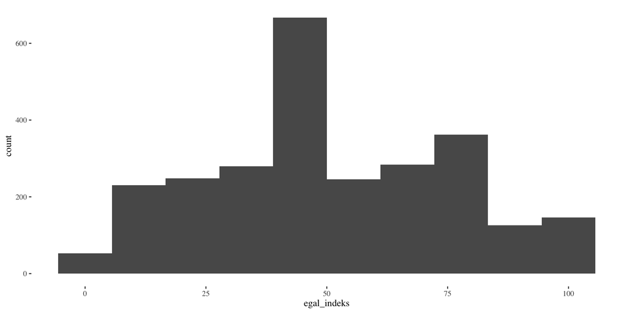

```r
vu_egal |>
  ggplot() +
  aes(x = egal_indeks) +
  geom_histogram(bins = 10) +
  ggthemes::theme_tufte()
```

## Indeksanalyse – egalitarisme og indkomst

**Kode**

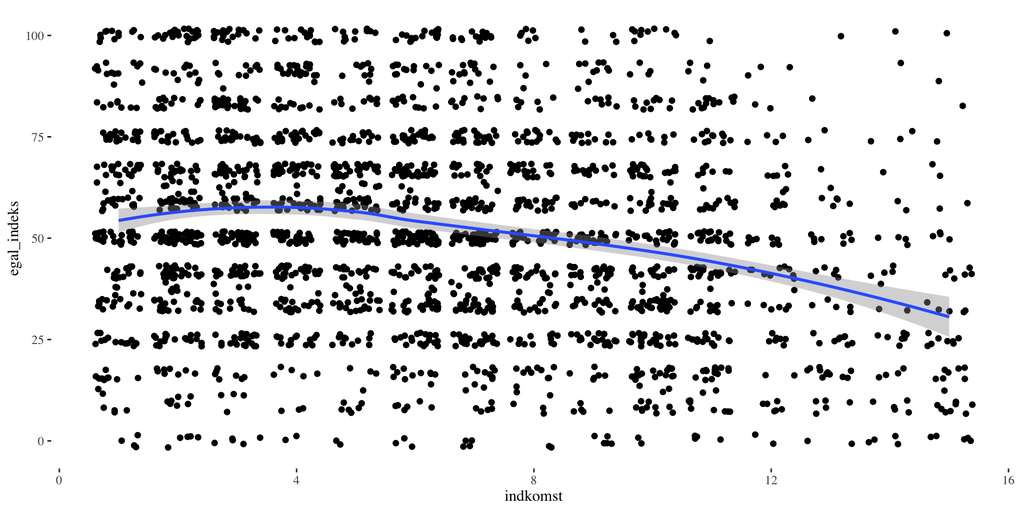

```r
vu_egal_merge <- vu_egal |>
  left_join(vu, join_by(id == Løbenummer))

vu_egal_merge |>
  mutate(indkomst = ifelse(Q78 %in% 1:15, Q78, NA)) |>
  ggplot() +
  aes(x = indkomst, y = egal_indeks) +
  geom_jitter() +
  geom_smooth(method = "loess") +
  ggthemes::theme_tufte()
```

## Indeksanalyse – egalitarisme og alder

**Kode**

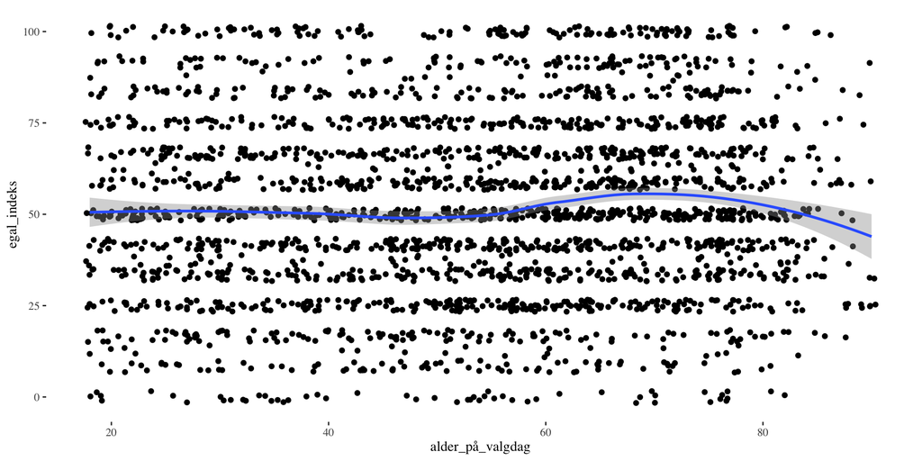

```r
vu_egal_merge |>
  ggplot() +
  aes(x = alder_på_valgdag, y = egal_indeks) +
  geom_jitter() +
  geom_smooth(method = "loess") +
  ggthemes::theme_tufte()
```

## Indeksanalyse – egalitarisme og parti

**Kode**

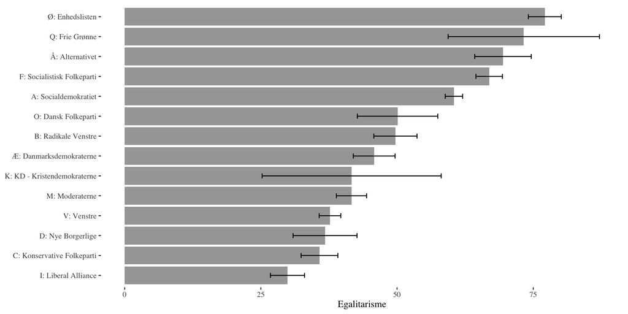

```r
vu_egal_merge |>
  filter(parti22 %in% 1:29) |>
  group_by(parti22) |>
  summarise(egal_indeks_avg = mean(egal_indeks, na.rm = TRUE),
            egal_indeks_low = mean_cl_normal(egal_indeks, na.rm = TRUE)$ymin,
            egal_indeks_upp = mean_cl_normal(egal_indeks, na.rm = TRUE)$ymax) |>
  ungroup() |>
  ggplot() +
  aes(x = fct_reorder(to_factor(parti22), egal_indeks_avg), y = egal_indeks_avg, ymin = egal_indeks_low, ymax = egal_indeks_upp) +
  geom_col(fill = "grey65") +
  geom_errorbar(width = .25) +
  ggthemes::theme_tufte() +
  labs(x = NULL, y = "Egalitarisme") +
  coord_flip()
```

## Indeksanalyse – egalitarisme og opbakning til MeToo

> MeToo-bevægelsen er gået for vidt (enig – uenig)

**Kode**

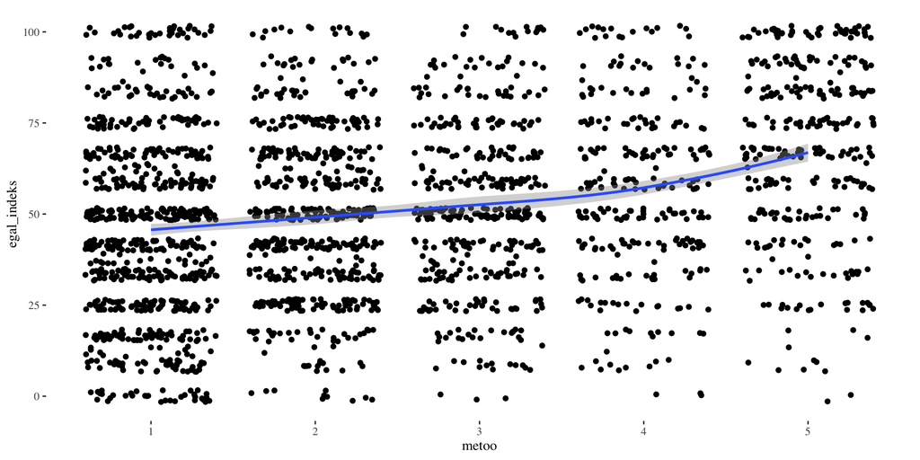

```r
vu_egal_merge |>
  mutate(metoo = ifelse(Q62_3 %in% 1:5, Q62_3, NA)) |>
  ggplot() +
  aes(x = metoo, y = egal_indeks) +
  geom_jitter() +
  geom_smooth(method = "loess") +
  ggthemes::theme_tufte()
```

## Indeksanalyse – egalitarisme og tillid til politikerne

> Politikerne er for ødsle med skatteborgernes penge (enig – uenig)

**Kode**

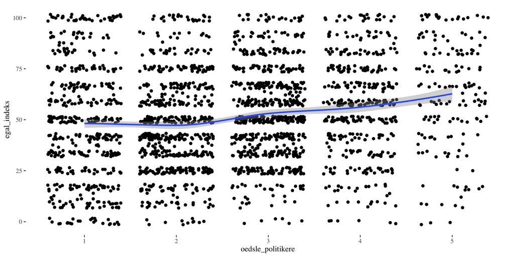

```r
vu_egal_merge |>
  mutate(oedsle_politikere = ifelse(Q52_7 %in% 1:5, Q52_7, NA)) |>
  ggplot() +
  aes(x = oedsle_politikere, y = egal_indeks) +
  geom_jitter() +
  geom_smooth(method = "loess") +
  ggthemes::theme_tufte()
```

## Indeksanalyse – egalitarisme og anti-elite sentiment

> Det sker tit, at eliten overtrumfer folkets vilje i Danmark (enig – uenig)

**Kode**

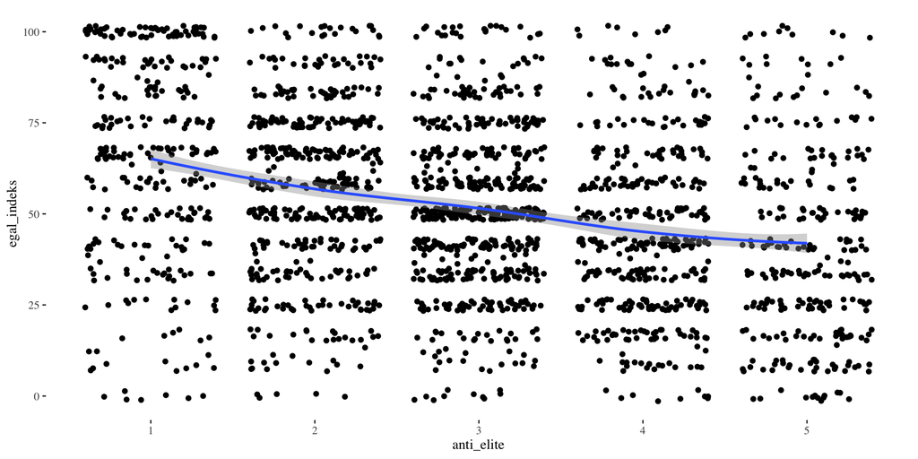

```r
vu_egal_merge |>
  mutate(anti_elite = ifelse(Q51_8 %in% 1:5, Q51_8, NA)) |>
  ggplot() +
  aes(x = anti_elite, y = egal_indeks) +
  geom_jitter() +
  geom_smooth(method = "loess") +
  ggthemes::theme_tufte()
```

# Eksempler

## Klimabevidsthed og ‘the local warming effect’

**RQ:** Hvordan påvirker usædvanlige temperaturer europæernes holdning til klimaforandringer?

**Personlig erfaring med ‘unormalt’ vejr** som heuristik:

- “*people who are confronted with a difﬁcult question sometimes answer an easier one instead*” (Kahneman 2003)

[figure not shown]

## Forskningsdesign

- Naturligt eksperiment
- [European Social Survey runde 8 (2016)](https://www.europeansocialsurvey.org/data/download.html?r=8) med masser af klimaspørgsmål
- Afhængig variabel: **Klimabevidsthed**  
  (0-100, indeks baseret på 6 spørgsmål)
- Uafhængig variabel: **Temperatur** over seneste 7 dage ift. “normalt” (30 år)
- Regressionsanalyse (OLS)

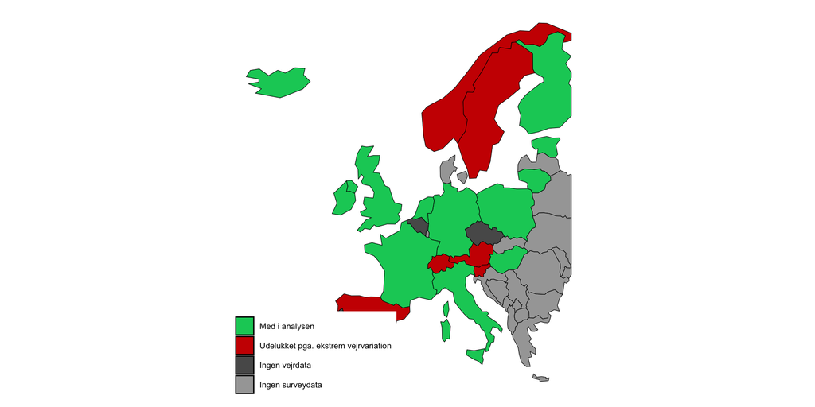

## Indeks: klimabevidsthed

1. Do you think the world’s climate is changing?
2. How much have you thought about climate change before today?
3. How worried are you about climate change?
4. Do you think that climate change is caused by natural processes, human activity, or both?
5. How good or bad do you think the impact of climate change will be on people across the world?
6. To what extent do you feel a personal responsibility to try to reduce climate change?

| Statistik | Værdi |
| --- | --- |
| Teoretisk variationsbredde | 0-100 |
| Unikke værdier | 325 |
| Gennemsnit | 61 |
| Q1, Q2 (median), Q3 | 50, 61, 71 |
| Typetal | 62 |

## Indeks: klimabevidsthed

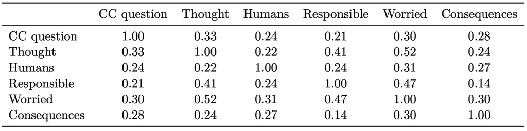

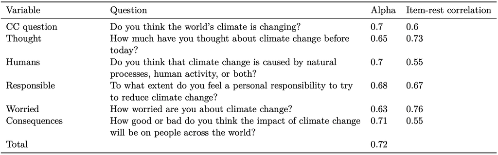

→ “*an index that reliably captures one dimension*”

## Resultater

- **Resultat:** svag positiv effekt
- **Oplevelser med varmt vejr øger klimabevidsthed**

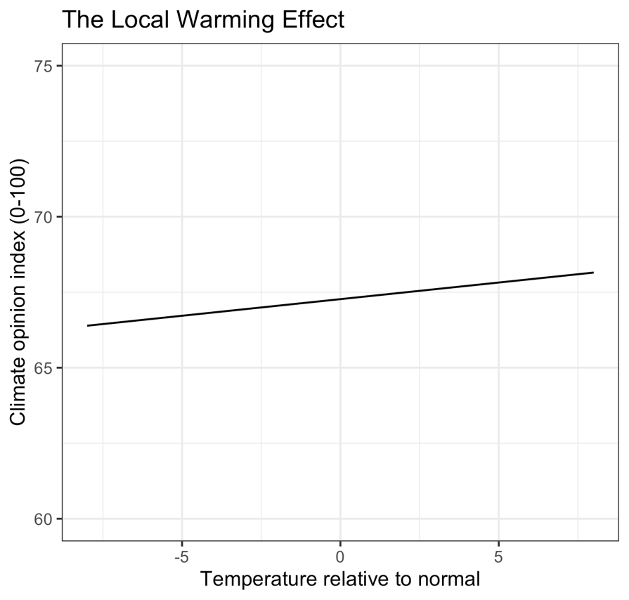

## Demokratiindeks

- Der findes mange indeks til at måle **demokrati/autokrati:**<sup>1</sup>
  - Varieties of Democracy (V-Dem) by the V-Dem project
  - Regimes of the World (RoW) by Lührmann et al. (2018), which use V-Dem data
  - Lexical Index of Electoral Democracy (LIED) by Skaaning et al. (2015)
  - Boix-Miller-Rosato by Boix et al. (2013, BMR)
  - Polity by the Center for Systemic Peace
  - Freedom House’s (FH) Freedom in the World
  - Bertelsmann Transformation Index (BTI) by the Bertelsmann Foundation
  - Economist Intelligence Unit’s (EIU) Democracy Index
[^2]: Se fx denne oversigt: https://ourworldindata.org/democracies-measurement

## Demokratiindeks

- Typisk en lang række indikatorer/spørgsmål, som **aggregeres** på avancerede måder
- Om de primært er **refleksive eller formative**, kan diskuteres
- Oftest *formative* i deres konceptualisering af demokrati
  - flerdimensionelle
  - komplette

## Freedom House – Freedom in the World indeks

> A country or territory is awarded 0 [mindst frihed] to 4 points [mest frihed] for each of 10 political rights indicators and 15 civil liberties indicators:
- Electoral Process (3 questions)
- Political Pluralism and Participation (4)
- Functioning of Government (3)
- Freedom of Expression and Belief (4 questions)
- Associational and Organizational Rights (3)
- Rule of Law (4)
- Personal Autonomy and Individual Rights (4)

**Alle indikatorers scorer summeres → teoretisk variationsbredde: 0 – 100 (40 + 60)**

## Freedom in the World status

[figure not shown]

Freedom House (2025), https://freedomhouse.org/reports/freedom-world/freedom-world-research-methodology

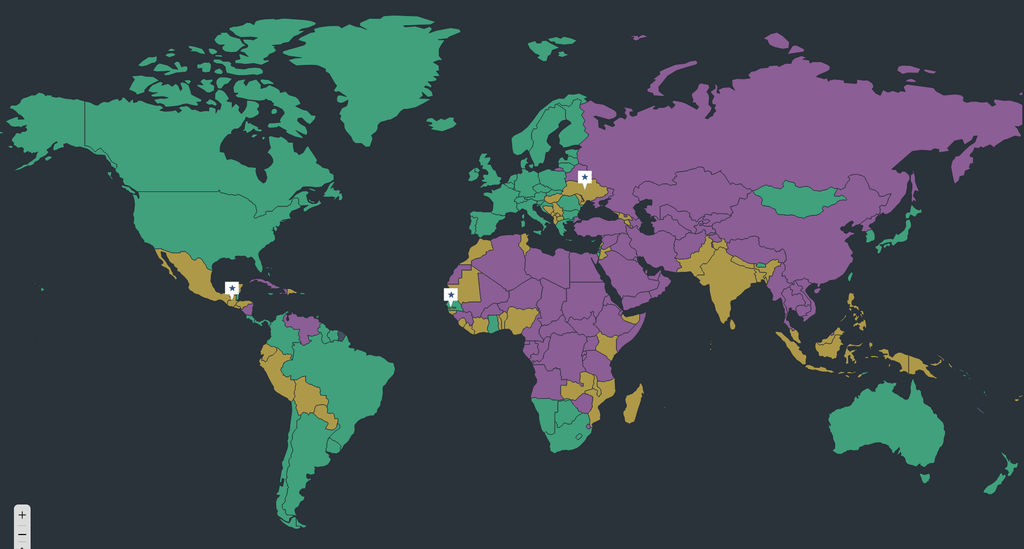

Freedom House (2025), https://freedomhouse.org/explore-the-map?type=fiw&year=2025

## V-Dem Liberal Democracy Index

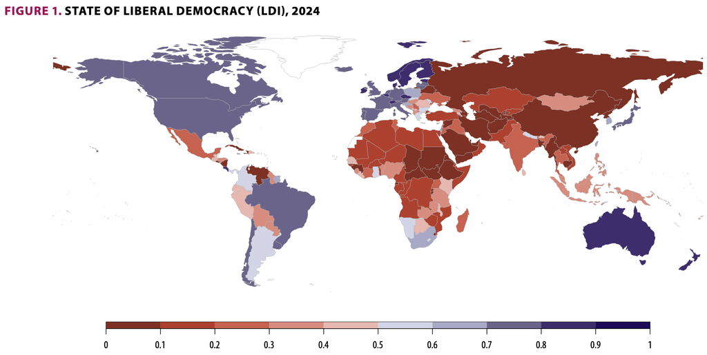

V-Dem LDI (2025), https://v-dem.net/documents/56/methodology.pdf

*Core concept (1) ← Democracy Indices (5) ← Democracy Components (5) ← Subcomponents, and related concepts (81) ← Indicators (500)*

## Eksempel fra politisk psykologi

- Wolak (2020), ‘Conflict Avoidance and Gender Gaps in Political Engagement’

> [G]ender gaps in **political engagement** cannot be explained by women’s greater **aversion to conflict** [*conflict avoidance*]. Instead, gender gaps are better understood as a product of men’s comparatively higher levels of **enjoyment of arguments and disagreements** [*conflict approach*]

*Do you agree or disagree with the following statements?* (Strongly agree, Agree, Neither agree nor disagree, Disagree, Strongly disagree)

1. I enjoy challenging the opinions of others [conflict approach]
2. I find conflicts exciting [conflict approach]
3. I hate arguments [conflict avoidance]
4. I feel upset after an argument [conflict avoidance]

## Eksempel fra politisk psykologi

- “I **create a scale** of *conflict-seeking* by **averaging** together responses to the items about *enjoying conflicts*”
- “as well as a scale of *conflict aversion* based on the two items about *negativity toward conflicts*”
- “The scales run **from 0 to 1**, with a **mean level of conflict-seeking of 0.47** and a **mean level of conflict aversion of 0.66**”
- “The **Cronbach’s alpha is 0.65** for both scales, which indicates somewhat lower internal consistency than would be desirable. That said, these alphas are higher than those found with other indicators of conflict orientations”
- Wolak præsenterer ingen korrelationer (item-item, gns. item-item, item-rest)
  - dog antageligt meget stærk (meget ens spørgsmål)

## Eksempel fra politisk psykologi

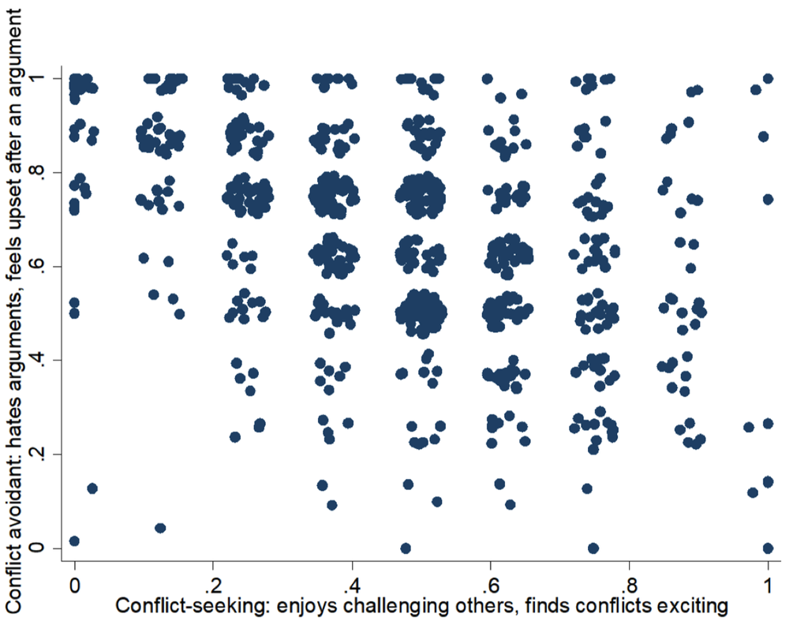

Kilde: Wolak (2020)

## Faktoranalyse

- *Antager at der findes latente variable (faktorer), som afspejles i de observerede variable*
- Kan være et nyttigt værktøj, især til **eksplorativ analyse**
- Og/eller som indledende skridt i **indekskonstruktion:**
  - udvælgelse af items og identifikation af dimensioner
  - men typisk ikke strengt nødvendigt
- **Kan hjælpe os med at identificere *hvilke variable, der ‘loader på’ hvilke bagvedliggende faktorer***
  - i virkeligheden (primært) designet til at reducere mange dimensioner (variable) til få
  - statistikken bag metoden er uigennemsigtig: ‘fitter’ en model baseret på variablenes covarians

## Faktoranalyse

- Som regel anvendes **faktorrotation**, der gør, at faktorerne indfanger så forskellig variation som muligt
- Udover *rotationsmetode* (fx “oblimin”) skal vi vælge *antallet af faktorer*
  - hvad kunne give mening?
  - prøv dig frem!

## Faktorrotation

*R roterer ‘koordinatsystemet’ for at maksimere kontrasterne/dimensionaliteten*

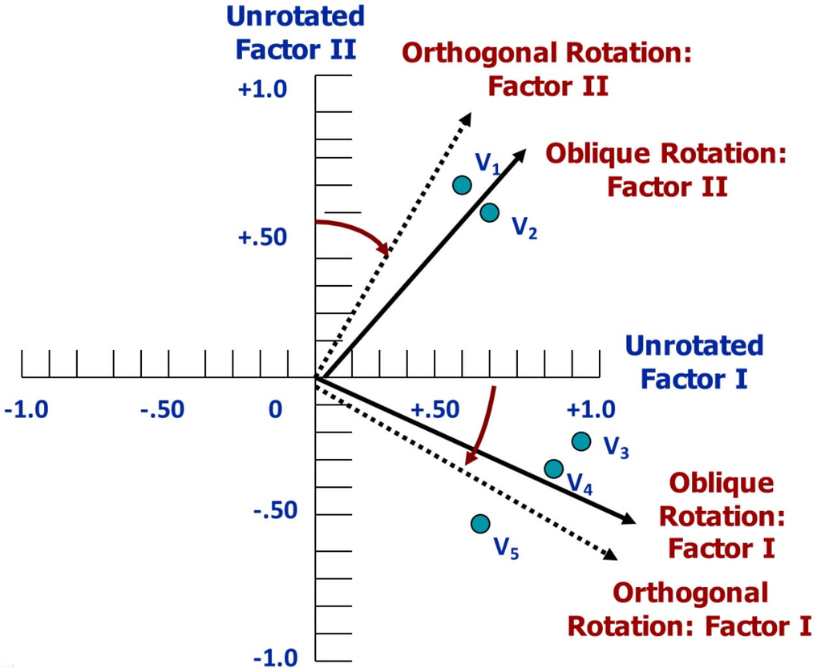

Kilde: https://devopedia.org/factor-analysis

## Faktoranalyse i R – egalitarisme

**Kode**

```r
library(psych)

# data
factor_model_data <- vu |>
  select(starts_with("Q49")) |>
  rename(egal_ulighed = Q49_9,
         egal_vilkaar = Q49_2,
         egal_dynamik = Q49_12) |>
  # behold kun nummeriske variable, fjern nogle variable igen (1, 10, 11, 13-18)
  select(where(is.numeric), -starts_with("Q49_1"))

# factor model
factor_model <- factor_model_data |>
  fa(nfactors = 3,
     rotate = "oblimin") # 'promax' er et godt alternativ (ens resultater)

# gem factor loadings (resultat)
factor_loadings <- factor_model$loadings
```

## Faktoranalyse i R – egalitarisme

**Kode**

```r
# vis factor loadings >= 0.4 (analyse)
ifelse(abs(factor_loadings) < 0.4, NA, factor_loadings) |>
  print(digits = 2, na.print = "")
```

```
              MR1 MR3  MR2
egal_vilkaar          0.44
Q49_3
Q49_4               1
Q49_5        0.54
Q49_6                 0.44
Q49_7                 0.61
Q49_8
egal_ulighed 0.73
egal_dynamik 0.77
```

```
      - egal_vilkaar: I politik bør man stræbe efter at skaffe alle de samme økonomiske vilkår, uanset uddannelse og beskæftigelse
      - 49_3: Jeg føler mig lige så meget som europæer, som jeg føler mig som dansker
      - 49_4: Der kan stadig spares masser af penge på at effektivisere den offentlige sektor, uden at det går ud over servicen til borgerne
      - 49_5: Der er for mange, der får sociale ydelser, uden at de trænger til det
      - 49_6: Staten har for lidt kontrol med de private investeringer
      - 49_7: Det var en fejl at hæve efterlønsalderen
      - 49_8: Det gør ingen større forskel, om det er det ene eller det andet parti, der vinder valget
      - egal_ulighed: Økonomisk ulighed gavner samfundet
      - egal_dynamik: For at skabe dynamik og fremgang i samfundet må man acceptere en vis grad af ulighed
```

## Eksempel fra politisk psykologi

*Wolak (2020) lavede faktisk en eksplorativ faktoranalyse før indeksene:*

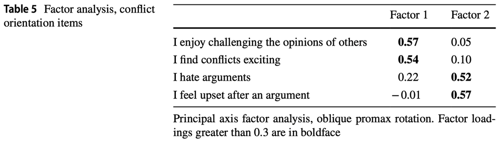

- “Results of […] factor analysis favor a **two-factor solution**”
- “I find that the two *conflict-seeking* items **load together on the first factor**,  
  while the *conflict aversion* items load together on the **second**”

## Opsummering

- **Indeks** er et redskab til at forbedre vores målinger
- Ofte består indekskonstruktion bare af at beregne et simpelt gennemsnit af få variable
  - men konstrueret og analyseret forsigtigt, grundigt og velovervejet med øje for **faldgruberne**, **målingsvaliditet** og **reliabiliteten**
  - og bag indekskonstruktion ligger en “model”, hvor observerbare indikatorer er udtryk for en fælles **latent variabel** (*refleksivt indeks*), eller den latente variabel formes af observerbare indikatorer (*formativt indeks*)
- **Faktoranalyse** er et andet redskab til eksplorative analyse af beslægtede variable
  - fx identificere/udvælge items (spørgsmål), som afspejler samme dimension i data og fx kunne kombineres i et indeks

## Næste uge

**Statistisk inferens**

- Sandsynlighedsfordelinger
- Normalfordelingen
- Konfidensintervaller
- Inferens og den centrale grænseværdisætning
- Mindre hands-on

*Vi anbefaler alle at **læse kapitel 7, ’Probability and Statistical Inference’, i Kellstedt & Whitten (2018), ‘The Fundamentals of Political Science Research’.** Kapitlet giver et godt overblik over ugens centrale koncepter og kan læses online på cambridge.org (via kb.dk).*